# HW01

Dominic Tu

9/9/2017

# *Snickerdoodle*

**Ingredients**

- 1/2 cup butter, softened
- 1/2 cup shortening
- 1 1/2 cups white sugar
- 2 eggs
- 2 teaspoons vanilla extract
- 2 3/4 cups all-purpose flour
- 2 teaspoons cream of tartar
- 1 teaspoon baking soda
- 1/4 teaspoon salt
- 2 teaspoons ground cinnamon

**Tools**

- spoon
- whisk
- pan
- oven

**Steps**

1. Preheat oven to 400 degrees F (200 degrees C).
2. Cream together butter, shortening, 1 1/2 cups sugar, the eggs and the vanilla. Blend in the flour, cream of tartar, soda and salt. Shape dough by rounded spoonfuls into balls.
3. Mix the 2 tablespoons sugar and the cinnamon. Roll balls of dough in mixture. Place 2 inches apart on ungreased baking sheets.
4. Bake 8 to 10 minutes, or until set but not too hard. Remove immediately from baking sheets.

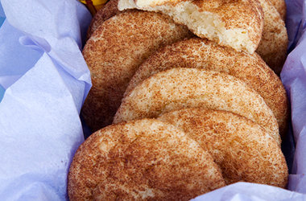

**Description**

> These wonderful cinnamon-sugar cookies became very popular with my friends at church. My pastor loves them! You will too! Crispy edges, and chewy centers; these cookies are a crowd pleaser for sure!

# Quadratic Equation

$$x = \frac{-b \pm \sqrt{b^2-4ac}}{2a}$$

**Description**

> In elementary algebra, the quadratic formula is the solution of the quadratic equation. There are other ways to solve the quadratic equation instead of using the quadratic formula, such as factoring, completing the square, or graphing. Using the quadratic formula is often the most convenient way.

# Comments and Relections

What things were hard, even though you saw them in class?

- Figuring out how to use Latex

What was easy(-ish) even though we haven’t done it in class?

- bulleting

Was this the first time you were using markdown? If yes, how do you feel about it?

- It was hard at first, but it got easier

If you have used markdown before, was there something new you learned while doing this assignment?

- N/A

Did you need help to complete the assignment? If so, what kind of help? Who helped you?

- I got help from my friend to write the quadratic equation with Latex

How much time did it take to complete this HW?

- 1hr

What was the most time consuming part?

- The quadratic equation part